# Santa Barbara Urchins

Eli Schulman

10/23/2021

Overview: The code wrangles then visualizes data on Urchins (Purple and Red) in the Santa Barbara county. Size, measured in cm and as the urchin’s diameter, is compared between species. Additionally, size as timeseries is shown.

*Data Citation:* Reed, D. 2020. SBC LTER: Reef: Long-term experiment: Kelp removal: Urchin size frequency distribution ver 20. Environmental Data Initiative. https://doi.org/10.6073/pasta/5a1e9ef03aa47bd2225c0bb98a02a63b.

```r
urchins <- read_csv(here("data", "urchins.csv")) %>%
  clean_names()
```

### Purple vs Red urchins (distributions of sizes)

This looks at urchin size across all sites and years

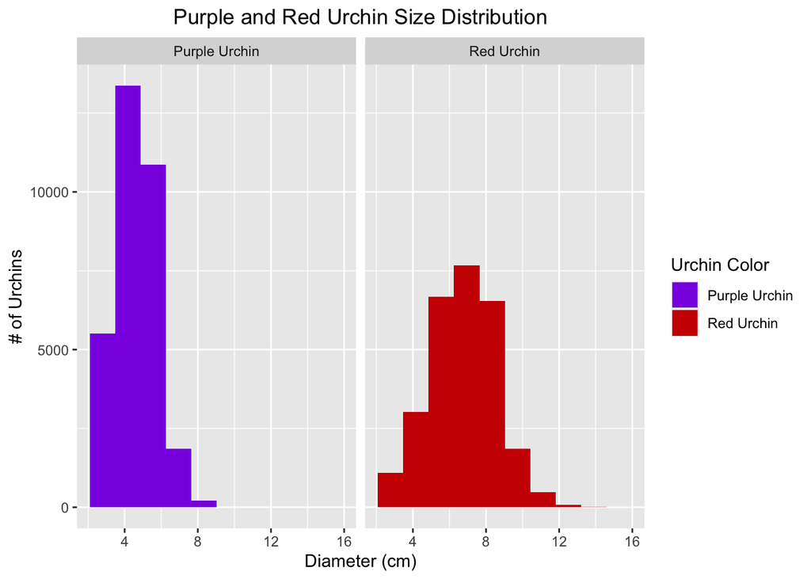

```r
ggplot(urchins, aes(x = size)) +
  geom_histogram(aes(fill = common_name), bins = 10) +
  labs(title = "Purple and Red Urchin Size Distribution",
       x = "Diameter (cm)",
       y = "# of Urchins",
       fill = "Urchin Color") +
# change legends color
  scale_fill_manual(values = c("blueviolet","red3")) +
# center the plot title
  theme(plot.title = element_text(hjust = .5)) +
  facet_wrap(~ common_name)
```

### Descriptive statistics for Urchins

This looks at urchin size across all sites and years

```r
urchins_stats <- urchins %>%
  group_by(common_name) %>%
# use signif(x,2) to show data with 2 significant figures (same as size observations)
  summarize(mean = signif(mean(size), 2),
            median = signif(median(size), 2),
            sd = signif(sd(size), 2),
            sample_size = n())

kable(urchins_stats,
# apply manual column headers for summary stats
      col.names = c('Species', 'Mean (cm)', 'Median (cm)', 'Standard Deviation (cm)', 'Sample Size'),
      caption = "Summary Statistics of Urchin Species Body Diameters") %>%
  kable_styling(full_width = FALSE)
```

Summary Statistics of Urchin Species Body Diameters

| Species | Mean (cm) | Median (cm) | Standard Deviation (cm) | Sample Size |
| --- | --- | --- | --- | --- |
| Purple Urchin | 4.5 | 4.5 | 1.2 | 31805 |
| Red Urchin | 6.8 | 7.0 | 1.9 | 27408 |

### Takeaway from urchin species distribution and stats summary:

#### The red urchins are more normaly distributed, and have a larger mean diameter relative to the purple urchins (6.78 cm vs 4.47 cm). Additionally, the red urchins have a larger spread in observed diameters compared to their mean.

### Purple urchins population sampling by site by year.

```r
purple_urchins <- urchins %>%
  filter(common_name == "Purple Urchin") %>%
  mutate(date = mdy(date)) %>%
  mutate(year = year(date)) %>%
  mutate(site_full = case_when(
# create new variable with the observation site full name, based on abrieviation
    site == "NAPL" ~ "Naples Reef",
    site == "AQUE" ~ "Arroyo Quenado Reef",
    site == 'CARP' ~ 'Carpinteria Reef',
    site == 'MOHK' ~ 'Mohawk Reef',
    site == 'IVEE' ~ 'Isla Vista Reef',
    TRUE ~ "NA"
  ))

# Create summary table
purple_urchins_trend <- purple_urchins %>%
  group_by(year, site_full) %>%
  summarize(pop = n())
```

### Graph Purple Urchin trends by site by year

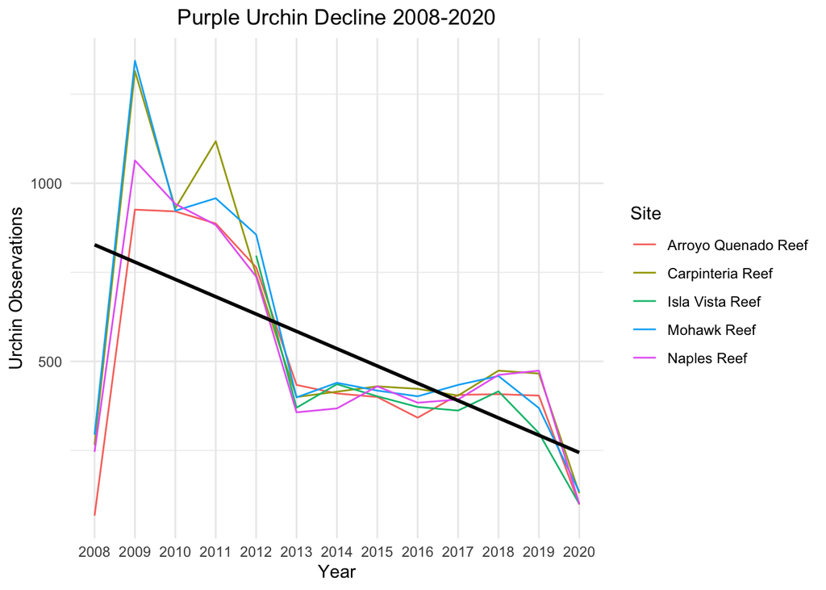

```r
ggplot(purple_urchins_trend, aes(x = year, y = pop)) +
  geom_line(aes(color = site_full)) +
# apply trend line
  geom_smooth(method = lm, se = FALSE, color = 'Black') +
  labs(title = "Purple Urchin Decline 2008-2020",
       x = "Year",
       y = "Urchin Observations",
       color = "Site") +
  theme_minimal() +
# center plot title
  theme(plot.title = element_text(hjust = .5)) +
# manually set the x-axis breaks
  scale_x_discrete(limit = c(2008:2020))
```